# Global Health Indicators Analysis: Life Expectancy and HIV Prevalence in 2020

Rodrigo

25-01-2026

## Introduction

This report examines two critical global health indicators for the year 2020: life expectancy and HIV prevalence in the general population. We visualize the geographic distribution of each indicator and explore the relationship between them.

## Data Preparation

### Summary Statistics for 2020

Global Health Indicators Summary Statistics (2020)

| Life Expectancy (Mean) | Life Expectancy (Min) | Life Expectancy (Max) | HIV Prevalence (Mean) | HIV Prevalence (Min) | HIV Prevalence (Max) |
| --- | --- | --- | --- | --- | --- |
| 72.1 | 52 | 85.1 | 1.57 | 0.1 | 26.9 |

## Life Expectancy in 2020

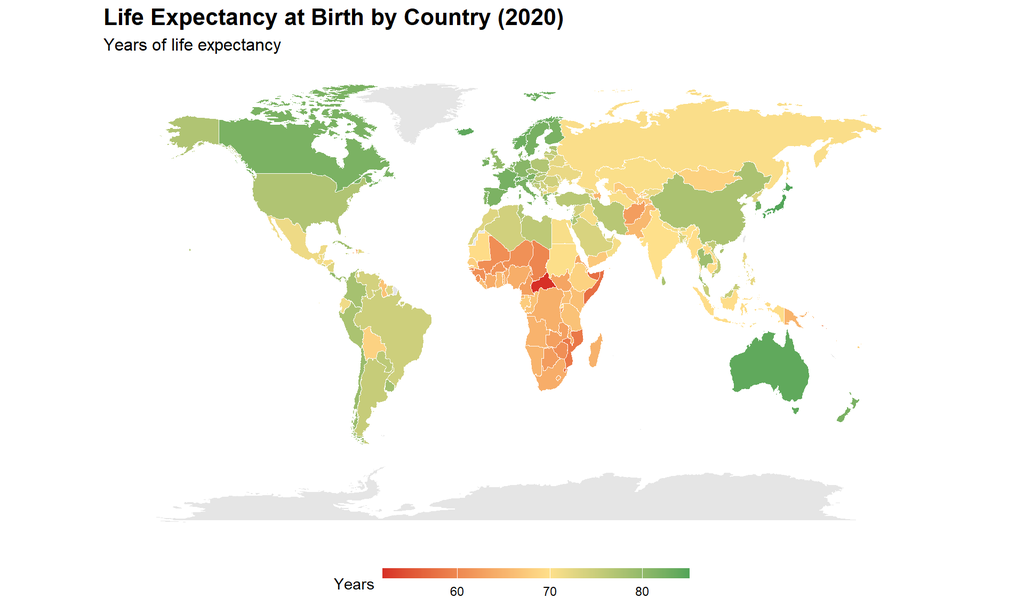

Global distribution of life expectancy in 2020

The map above shows significant geographic variation in life expectancy across the world in 2020. Higher-income regions, particularly in Europe, North America, and parts of Asia, generally exhibit higher life expectancy (shown in green), while lower-income regions, especially in Sub-Saharan Africa, show lower life expectancy (shown in red).

## HIV Prevalence in 2020

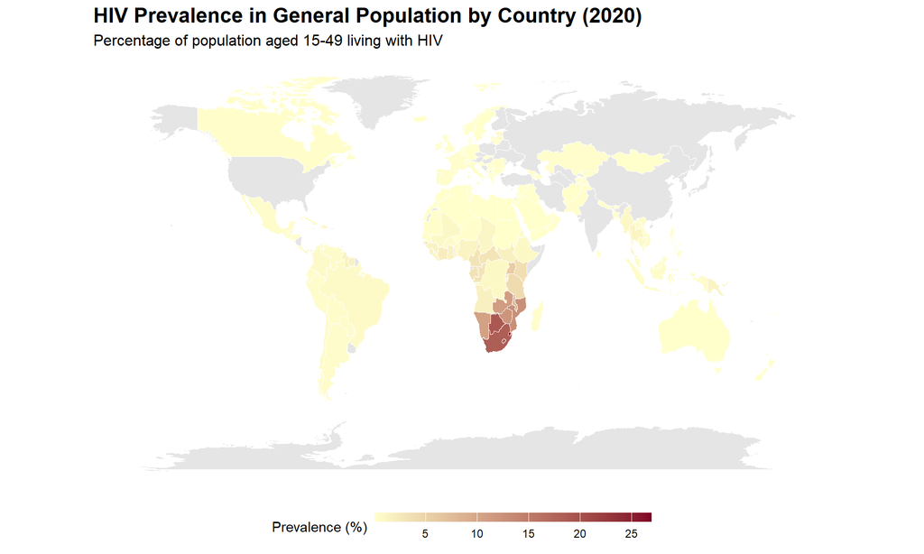

Global distribution of HIV prevalence in 2020

HIV prevalence shows a distinct geographic pattern, with Sub-Saharan Africa experiencing the highest rates (shown in darker red). Most other regions show relatively low prevalence rates (shown in lighter yellow).

## Relationship Between Life Expectancy and HIV Prevalence

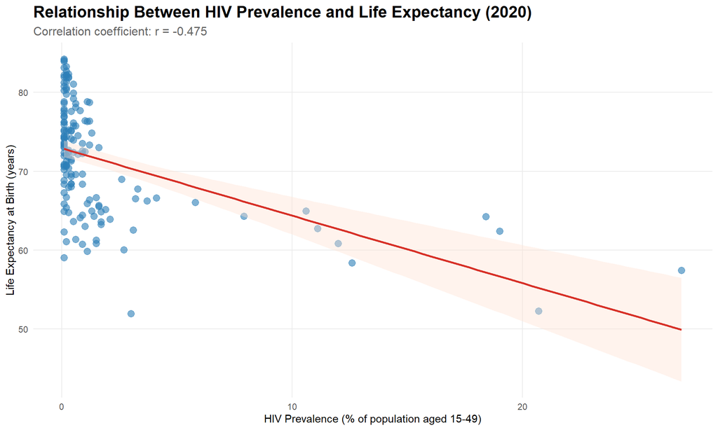

Relationship between life expectancy and HIV prevalence in 2020

### Correlation Analysis

Correlation Statistics

| Metric | Value |
| --- | --- |
| Correlation Coefficient | -0.475 |
| Number of Countries | 151.000 |

## Interpretation

This analysis highlights the critical importance of sustained investment in HIV prevention, treatment programs, and complete healthcare systems to improve life expectancy in the most affected countries.

## Personal Reflection

To me, it was amazing to see how fast and easy basic analysis is. Using AI really simplifies the process of loading data, merging, wrangling and conducting analysis, and also, it provides a very quick way to make graphs. Many times I’d spend a lot of time just modifying the geom features in a graph. Using this software is by far more straightforward and easier than copying and pasting from an online LLM.

But, I think I should be cautious, as human supervision may still be needed to follow up the coding process, and interpret results carefully.

I’m uncertain on how more complex analysis are made like multiple regression, time trends survivorship analysis, etc. But it would be very interesting to test.

The most difficult to me was starting the project and finding the button to actually create a new file. As I continue practicing I will improve my understanding of this particular software, which will probably make it easy.

Finally I am still to try the program using spanish.

Overall using AI for data analysis this way can have a great impact in my productivity.